# Predicting Housing Valuations In a Volatile Economy

# 1 Description

In this project we analyse and predict housing value in a volatile market over a four years window.  
The dataset is from kaggle.com, including the characteristics of sold houses and the microeconomics indexes.  
While cleaning the data, we use ggplot to plot variables, making 24 graphs (including one interactive plot).  
We use Multivariate Imputation by Chained Equations (mice), for missing variables imputation.  
Finally we run a random search XGBoost with 1000 draws to find the best model, which outperforms simple regression by about 50 percent.

```r
# == Data Visualisation and Wrangling == #
library(tidyverse)
library(data.table)
library(lubridate)
library(ggthemes)

# == Imputing Missing Data == #
library(mice)
library(lattice)

# == Interactive Time series == #
library(dygraphs)
library(xts)

# == XGBoost == #
library(xgboost)
library(Metrics)
```

#### 1.0.0.1 set seed

```r
set.seed(1234)
```

# 2 Loading data and initial prepration

#### 2.0.0.1 set seed

```r
set.seed(1234)
```

```r
df = read.csv("data.csv" , header= TRUE)
macro = read.csv("macro.csv" , header= TRUE)
```

# 3 checking the data

The data dimensions

```r
dim(df)
```

```
## [1] 30471   292
```

Converting data columns to appropriate format.

```r
df$timestamp <- as.Date(df$timestamp)
macro$timestamp <- as.Date(macro$timestamp)
```

We also limit the number of variables/columns as this project is a demonstration and the resources (time/computation) are limited for intended analysis.

```r
df <- df %>% select(timestamp,full_sq, life_sq, floor,
                       max_floor, build_year, num_room,
                       kitch_sq, state, material,
                       product_type, full_all, price_doc)

macro_s <- macro %>% select(timestamp,usdrub,unemployment)

dim(df)
```

```
## [1] 30471    13
```

```r
dim(macro_s)
```

```
## [1] 2484    3
```

Converting data columns to appropriate format.

```r
df$timestamp <- as.Date(df$timestamp)
macro$timestamp <- as.Date(macro$timestamp)
```

We join the data sets.

```r
df <- df %>% left_join(macro_s)
dim(df)
```

```
## [1] 30471    15
```

```r
split <- sample(c(rep(0, 0.75 * nrow(df)), rep(1, 0.25 * nrow(df))))
train = df[split == 0 , ]
test = df[split == 1 , ]
```

```r
dim(train)
```

```
## [1] 22854    15
```

```r
dim(test)
```

```
## [1] 7617   15
```

# 4 Explanatory Data Analysis

For aesthetic reasons, some outliers might have been removed from the graphs and they are not demonstrated separatly. As we move forward through data, cleaning might take place as needed.

## 4.1 internal house charachteritics

Here we list the house internal characteristics and analyse them

### 4.1.1 full_sq

Definition: total area in square meters, including loggias, balconies and other non-residential areas  
Here we table the data and inspect full_Sq values. There are observations with value below 10 square meter and as they are suspicious, so we further investigate them.

```r
table(train$full_sq)
```

```
##
##    0    1    5    6   12   13   14   15   16   17   18   19   20   21   22   23
##    2   19    1    1    2    7    7   11    7   13   15   19   19    8    6    6
##   24   25   26   27   28   29   30   31   32   33   34   35   36   37   38   39
##   13   19   44   75   64  198  299  404  620  234  475  441  399  882 1404  750
##   40   41   42   43   44   45   46   47   48   49   50   51   52   53   54   55
##  654  581  510  628  768  688  365  265  268  181  292  582  496  493  430  314
##   56   57   58   59   60   61   62   63   64   65   66   67   68   69   70   71
##  347  347  432  427  475  404  362  477  471  228  112  135  110  115  106  118
##   72   73   74   75   76   77   78   79   80   81   82   83   84   85   86   87
##  168  186  350  241  291  333  234  344  128  102  200   92  158   99   53   40
##   88   89   90   91   92   93   94   95   96   97   98   99  100  101  102  103
##   39   47   42   28   34   24   32   35   47   28   30   29   49   36   55   25
##  104  105  106  107  108  109  110  111  112  113  114  115  116  117  118  119
##   29   16   19   20   13   14   13    7   25   12   11   17   15   17   12   12
##  120  121  122  123  124  125  126  127  129  130  131  132  133  134  135  136
##   14   16    8   14   12   14   15   10    6    2    7    2    7   21   14    8
##  137  138  139  140  141  142  143  144  146  147  148  149  150  151  153  154
##    7   12    1    2    1    6    6    3    8    7    2    2    6    3    1    2
##  155  156  157  158  159  160  161  164  165  166  167  168  169  170  172  173
##    9    8    3    1    4    6    1    1    8    7   12    1    6    4    4    1
##  174  177  178  179  181  182  183  184  185  186  187  195  197  199  202  204
##    1    1    2    2    2    1    1    1    1    1    2    1    2    1    2    1
##  206  207  209  210  211  216  219  220  226  275  291  303  353  412  461  603
##    2    1    1    1    1    1    2    1    1    1    1    1    1    1    1    1
##  634  637 5326
##    1    1    1
```

If the area of a house is zero, we convert it to NA.

```r
train[,"full_sq"][train[,"full_sq"] == 0] <- NA
```

The following is a scatter plot of the price by property area.

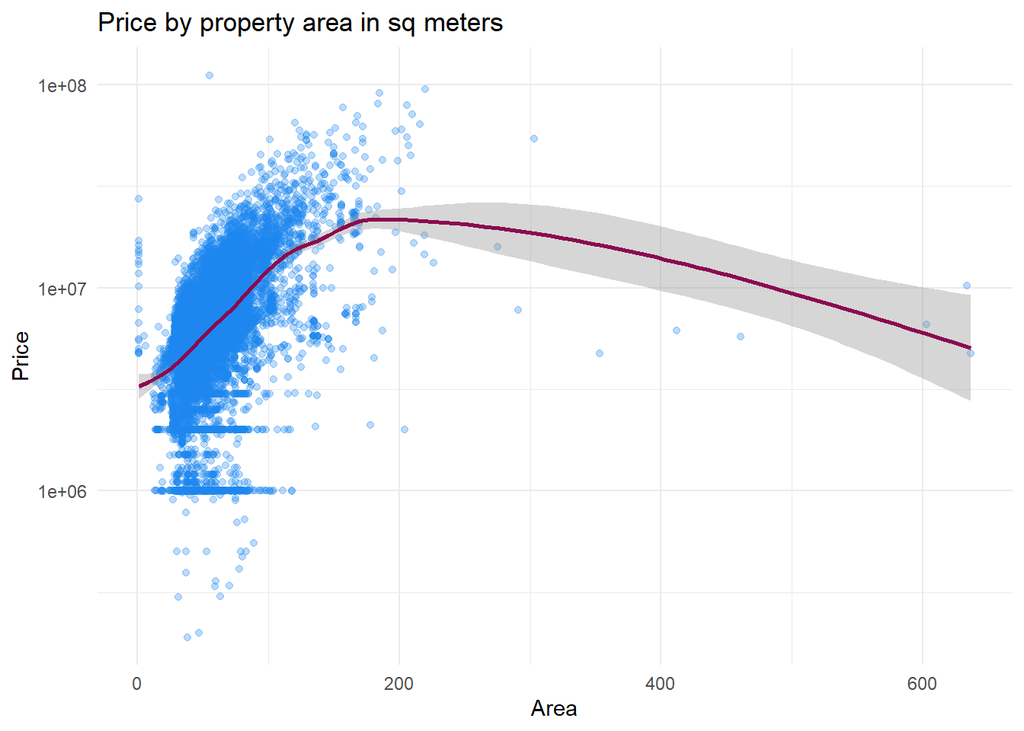

```r
train %>%
    filter(full_sq < 1000) %>%
    ggplot(aes(x=full_sq, y=price_doc)) +
    geom_point(color='dodgerblue2', alpha=0.3) +
    geom_smooth(color='deeppink4') +
    scale_y_log10() +
    labs(x='Area', y='Price', title='Price by property area in sq meters') +
    theme_minimal()
```

we graph the suspicious properties, those with an area below 20 square meter. As we are not able to further investigate the matter, we let them to stay as they are.

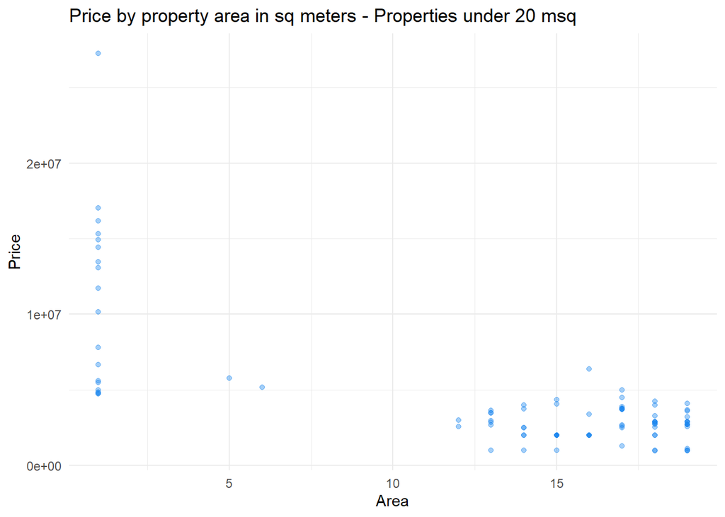

```r
train %>%
    filter(full_sq < 20) %>%
    ggplot(aes(x=full_sq, y=price_doc)) +
    geom_point(color='dodgerblue2', alpha=0.4) +
    theme_minimal() +
    labs(x='Area', y='Price', title='Price by property area in sq meters - Properties under 20 msq')
```

### 4.1.2 life_sq

Next we graph leaving area against the full property area, we expect to see all values of living are below that of property area. We remove outliers from the graph to have a better view of the relation.

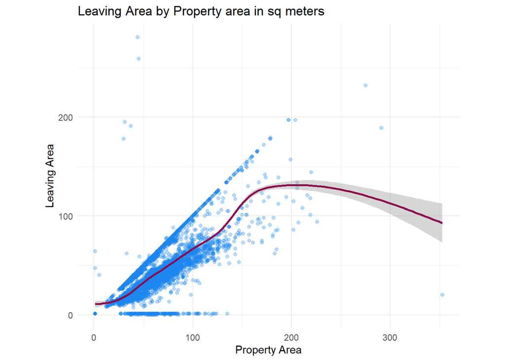

```r
train %>%
    filter(full_sq < 400 & life_sq <300) %>%
    ggplot(aes(y=life_sq, x=full_sq)) +
    geom_point(color='dodgerblue2', alpha=0.3) +
    geom_smooth(color = 'deeppink4') +
    coord_fixed(ratio = 1)+
    labs(y='Leaving Area' , x='Property Area',
         title='Leaving Area by Property area in sq meters') +
    theme_minimal()
```

The following line of code removes the living area value of observations in which the property area is smaller than living area, as we are assuming the property value is probably more reliable.

```r
train[,"life_sq"][train[,"life_sq"]>train[,"full_sq"]] <- NA
```

Now we take a look at the distribution of the leaving area.

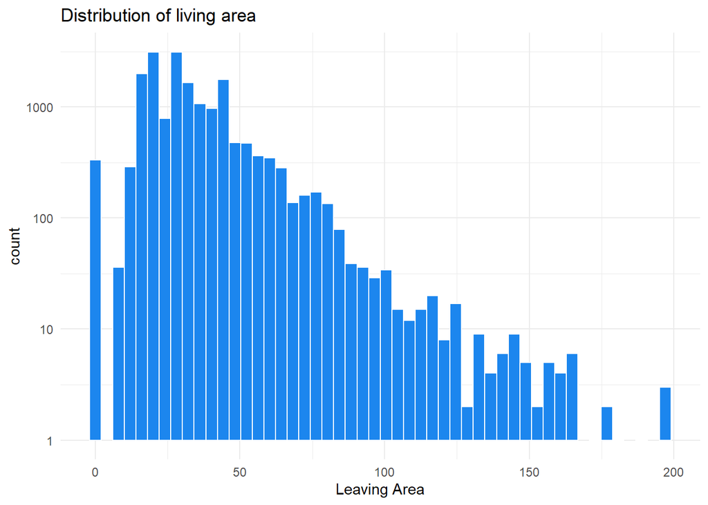

```r
train %>%
    filter(full_sq < 1000 & life_sq < 200) %>%
    ggplot(aes(x=life_sq)) +
    geom_histogram(color= "white" ,fill='dodgerblue2', bins=50) +
    scale_y_log10()+
    labs(x='Leaving Area',
         title='Distribution of living area') +
    theme_minimal()
```

### 4.1.3 kitch_sq

we graph the area of kitchen against the property area. As one could easily justify it, the kitchen area, increases with a small slope.

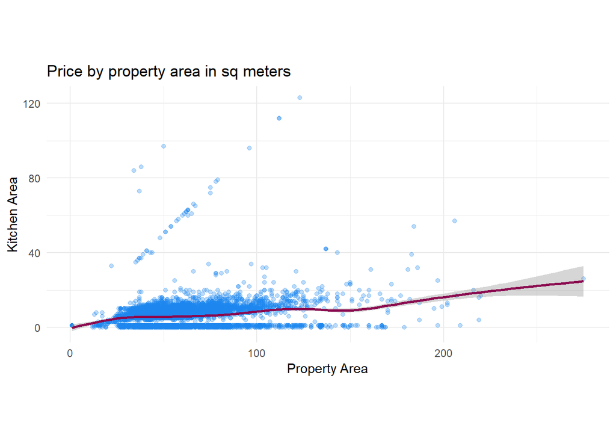

```r
train %>%
    filter(full_sq < 300 & kitch_sq <500) %>%
    ggplot(aes(y=kitch_sq, x=full_sq)) +
    geom_point(color='dodgerblue2', alpha=0.3) +
    geom_smooth(color = 'deeppink4') +
    coord_fixed(ratio = 1) +
    labs(y='Kitchen Area', x='Property Area',
         title='Price by property area in sq meters')+
    theme_minimal()
```

We remove kitchen values bigger than the prperty area.

```r
train[,"kitch_sq"][train$kitch_sq>train$full_sq] <- NA
```

Here we have the histogram of kitchen area.

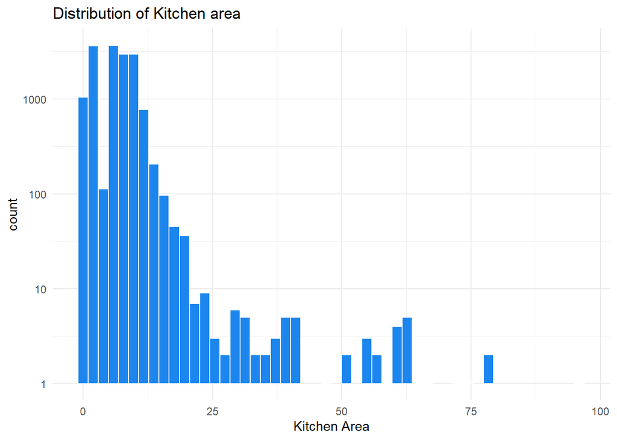

```r
train %>%
    filter(kitch_sq < 100 ) %>%
    ggplot(aes(x=kitch_sq)) +
    geom_histogram(color= "white" ,fill='dodgerblue2', bins=50) +
    scale_y_log10() +
    labs(x='Kitchen Area',
         title='Distribution of Kitchen area') +
    theme_minimal()
```

### 4.1.4 floor

Here we have the distribution of variable floor.

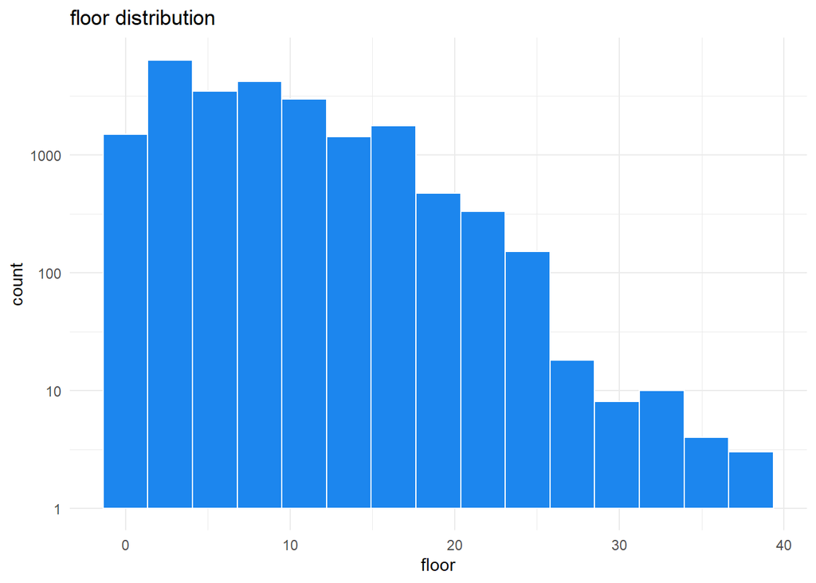

```r
train %>%
    filter(floor < 40) %>%
    ggplot(aes(x=floor)) +
    geom_histogram(color= "white" ,fill='dodgerblue2', bins=15) +
    scale_y_log10() +
    labs(x='floor',
         title='floor distribution') +
    theme_minimal()
```

### max_floor Here the max floor

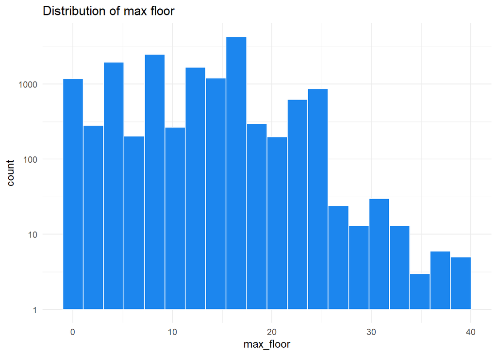

```r
train %>%
    filter(max_floor < 40) %>%
    ggplot(aes(x=max_floor)) +
    geom_histogram(color= "white" ,fill='dodgerblue2', bins=20) +
    scale_y_log10() +
    ggtitle('Distribution of max floor')+
    theme_minimal()
```

We check the property floor against the maximum number of floors. we cap the graph axises on 25 floors and 25 max floors.

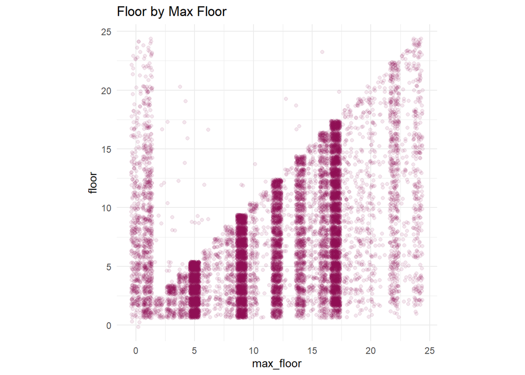

```r
train %>%
  filter(max_floor < 25 & floor < 25) %>%
  ggplot(aes(y= floor , x= max_floor)) +
  geom_jitter(color='deeppink4', alpha=0.1) +
  coord_fixed(ratio = 1) +
  labs(x='max_floor', y='floor', title='Floor by Max Floor')+
    theme_minimal()
```

We remove max_floors that are smaller than floors.

```r
train$max_floor[train$max_floor<train$floor] <- NA
```

### 4.1.5 material

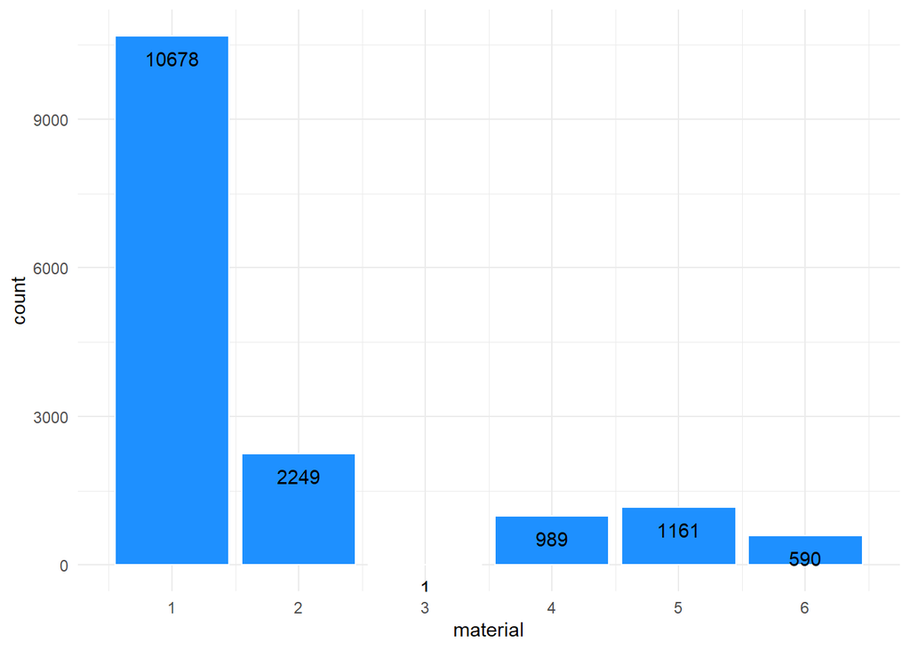

```r
train %>%
  ggplot( aes(x=material)) +
  geom_bar(fill = "dodgerblue1", color = "white") +
  scale_x_continuous(breaks = seq(1,6,1)) +
  geom_text(stat='count', aes(label=..count..), vjust=2)+
    theme_minimal()
```

### 4.1.6 build_year

We first inspect the data using table command.

```r
table(train$build_year)
```

```
##
##        0        1        3       71      215     1876     1886     1890
##      406      270        1        1        1        1        1        3
##     1895     1896     1900     1904     1906     1907     1910     1912
##        1        2        2        1        1        1        4        5
##     1914     1915     1917     1920     1924     1925     1926     1927
##        2        5       13        1        3        1        6        8
##     1928     1929     1930     1931     1932     1933     1934     1935
##        9       10        3        4        6        5        9        8
##     1936     1937     1938     1939     1940     1941     1943     1946
##        2       10        4        6       12        1        2        2
##     1947     1949     1950     1951     1952     1953     1954     1955
##        3        1       17       18       33       18       29       44
##     1956     1957     1958     1959     1960     1961     1962     1963
##       38       85      135      166      262      226      268      230
```

[output cut: 16 more lines]

In main dataset we set the build years before 1860 and after 2018 to NA

```r
train$build_year[train$build_year<1860 |train$build_year> 2018 ] <- NA
```

The plot of price against the built year is as follows. As it can been seen some properties values have been rounded (either by operator or sellers)

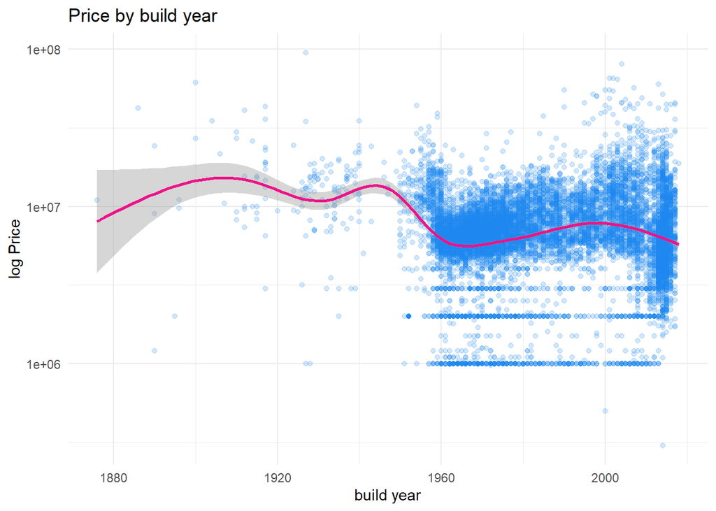

```r
train %>%
    filter(build_year >1860) %>%
    ggplot(aes(y=price_doc, x=build_year)) +
    geom_point(color = 'dodgerblue2' ,alpha = .2)+
    geom_smooth(color = 'deeppink2') +
    scale_y_log10()+
    labs(x='build year', y='log Price', title='Price by build year')+
    theme_minimal()
```

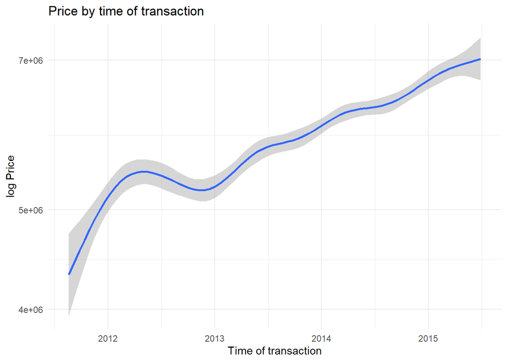

```r
train %>%
  ggplot(aes(y=price_doc , x= (timestamp) )) +
  geom_smooth()+
  scale_y_log10()+
  labs(x='Time of transaction', y='log Price', title='Price by time of transaction')+
    theme_minimal()
```

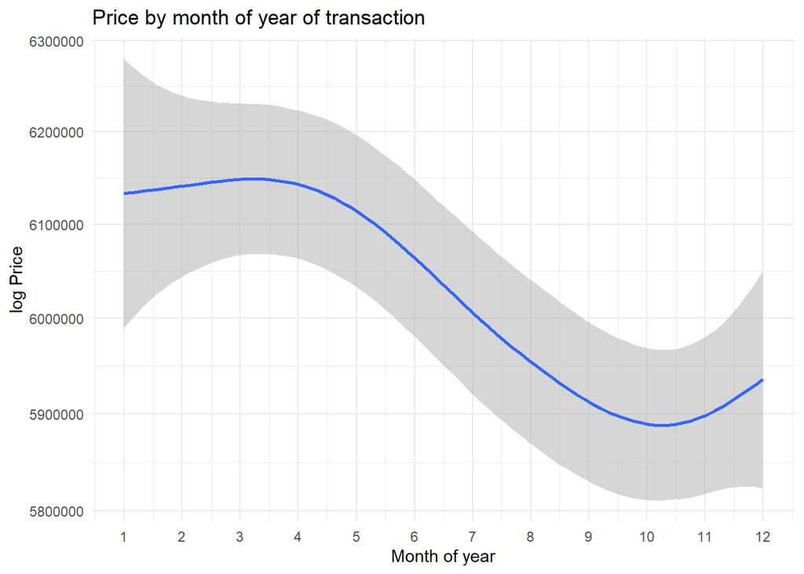

```r
train %>%
  mutate(year = year(timestamp)) %>%
  ggplot(aes(y=price_doc , x= month(timestamp) , color = year)) +
  geom_smooth()+
  scale_y_log10()+
  scale_x_continuous(breaks = seq(1,12,1)) +
  labs(x='Month of year', y='log Price', title='Price by month of year of transaction')+
    theme_minimal()
```